# Entendendo modelos mistos: o caso do sono e do tempo de reação

Aula introdutória com o dataset sleepstudy (lme4), base para o Módulo 9

Author

Marcelo Silva

**NoteComo usar este arquivo**

Esta é a aula que vem antes do estudo de caso dos esferoides. O objetivo aqui é construir a intuição: o que muda quando tratamos medidas repetidas do mesmo sujeito como correlacionadas em vez de independentes. Usamos um dataset embutido no R (`sleepstudy`), então não dependemos de arquivos externos. Na aula, digite o código junto com o professor; o template vazio está na pasta ao lado.

## 1 Por que esta aula existe

No estudo de caso dos esferoides (Módulo 9) os dados eram pareados: cada esferoide medido em dois tempos. Aqui usamos um exemplo mais simples para ver a mesma ideia por dentro, com um dataset que já vem no R. Sem entender este passo, o caso dos esferoides parece mágica.

O ponto central: quando o mesmo sujeito (pessoa, animal, placa) é medido várias vezes, as medidas não são independentes. Quem ignora isso tira conclusões erradas. O modelo misto é a ferramenta que corrige isso.

## 2 O dataset sleepstudy

O `sleepstudy` acompanha 18 pessoas submetidas a privação de sono. Para cada pessoa, medimos o tempo de reação (em milissegundos) em 10 dias consecutivos de privação. Cada pessoa tem, portanto, 10 medidas.

Isso é idêntico a muitos desenhos da pesquisa: pacientes acompanhados em várias consultas, animais pesados em vários dias, placas de cultura lidas em vários tempos. A mesma estrutura de medidas repetidas.

## 3 Pacotes

```r
# Carregue os pacotes necessários para a aula
library(lme4)        # ajuste de modelos mistos (lmer)
library(lmerTest)    # p-valores para os efeitos fixos do lmer
library(ggplot2)     # gráficos
library(dplyr)       # manipulação de dados
library(emmeans)     # médias ajustadas a partir do modelo
```

## 4 Carregando e conhecendo os dados

```r
# Carregue o dataset e veja a estrutura (18 sujeitos, 10 dias cada)
data(sleepstudy)
str(sleepstudy)
```

```
'data.frame':   180 obs. of  3 variables:
 $ Reaction: num  250 259 251 321 357 ...
 $ Days    : num  0 1 2 3 4 5 6 7 8 9 ...
 $ Subject : Factor w/ 18 levels "308","309","310",..: 1 1 1 1 1 1 1 1 1 1 ...
```

```r
cat("\nSujeitos distintos:", nlevels(sleepstudy$Subject),
    "| observações:", nrow(sleepstudy), "\n")
```

```
Sujeitos distintos: 18 | observações: 180
```

As colunas são:

- `Reaction`: tempo de reação médio (ms).
- `Days`: dias de privação de sono (0 a 9, numérico).
- `Subject`: identificador da pessoa (fator com 18 níveis).

## 5 Olhando os dados de perto

Antes de qualquer modelo, olhe. A intuição nasce do gráfico.

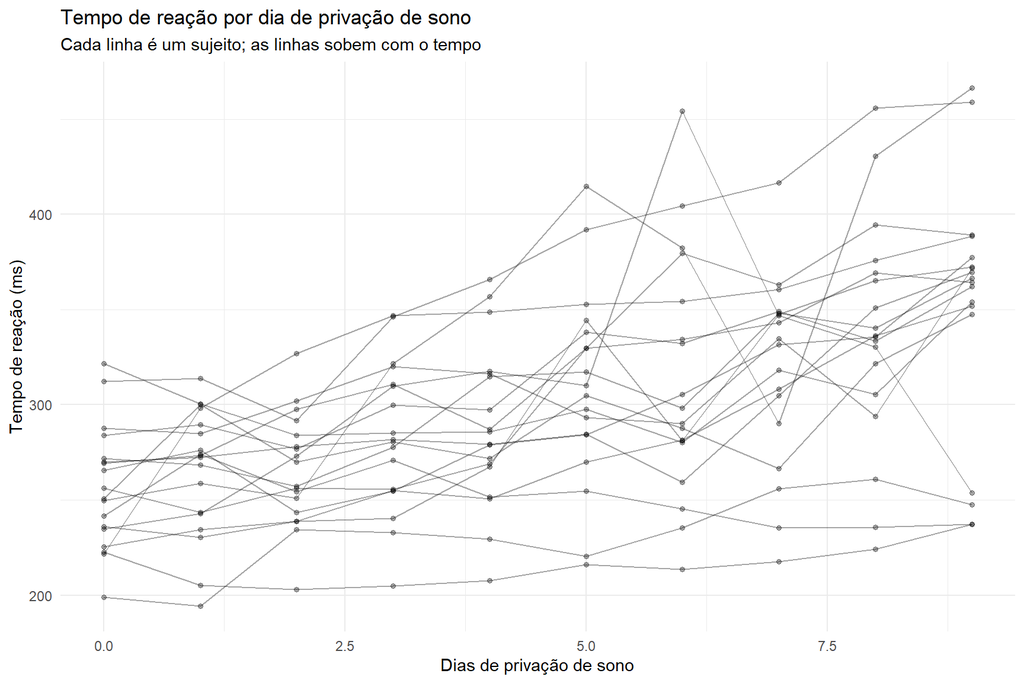

```r
# Plote o tempo de reação ao longo dos dias, linha por sujeito
ggplot(sleepstudy, aes(x = Days, y = Reaction, group = Subject)) +
  geom_point(alpha = 0.35, size = 1.2) +
  geom_line(alpha = 0.35) +
  labs(
    title = "Tempo de reação por dia de privação de sono",
    subtitle = "Cada linha é um sujeito; as linhas sobem com o tempo",
    x = "Dias de privação de sono",
    y = "Tempo de reação (ms)"
  ) +
  theme_minimal()
```

O que se vê: quase todas as linhas sobem (o tempo de reação piora com a privação). Mas cada sujeito começa de um ponto diferente. Alguns já reagem devagar no dia 0; outros, rápido. Essa diferença de ponto inicial é exatamente o que o modelo misto precisa captar.

## 6 O erro de tratar tudo como independente

A tentação é rodar uma regressão comum (`lm`), como se cada linha fosse um sujeito diferente. Vamos ver o que ela entrega.

```r
# Ajuste a regressão comum (IGNORA que há sujeitos repetidos)
modelo_lm <- lm(Reaction ~ Days, data = sleepstudy)

cat("\nCoeficiente de Days pela regressão comum:\n")
```

```
Coeficiente de Days pela regressão comum:
```

```r
print(coef(modelo_lm))
```

```
(Intercept)        Days
  251.40510    10.46729
```

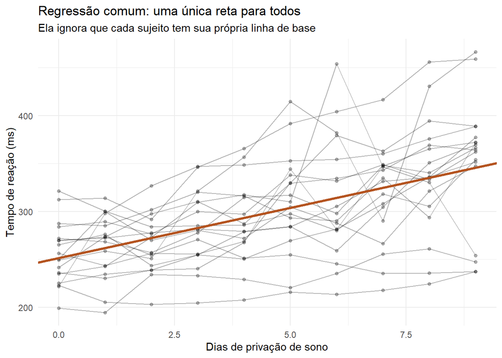

```r
# Sobreponha a reta ajustada no gráfico
ggplot(sleepstudy, aes(x = Days, y = Reaction, group = Subject)) +
  geom_point(alpha = 0.3, size = 1.2) +
  geom_line(alpha = 0.3) +
  geom_abline(intercept = coef(modelo_lm)[1],
              slope = coef(modelo_lm)[2],
              colour = "#b4531f", linewidth = 1.1) +
  labs(
    title = "Regressão comum: uma única reta para todos",
    subtitle = "Ela ignora que cada sujeito tem sua própria linha de base",
    x = "Dias de privação de sono",
    y = "Tempo de reação (ms)"
  ) +
  theme_minimal()
```

A reta é única. Ela diz a média do efeito dos dias, mas trata as 180 medidas como se fossem 180 pessoas diferentes. O erro-padrão fica subestimado, porque o método “acha” mais independência do que existe. É o mesmo problema que teríamos nos esferoides se ignorássemos o pareamento.

## 7 O modelo misto: cada sujeito com sua própria linha de base

Agora o modelo misto. Parte fixa: o efeito dos `Days` (o que queremos estimar e interpretar). Parte aleatória: cada sujeito tem sua própria interceptação, `(1 | Subject)`.

```r
# Ajuste o modelo misto com interceptação aleatória por sujeito
modelo_ri <- lmer(Reaction ~ Days + (1 | Subject),
                  data = sleepstudy)

cat("\nResumo do modelo com interceptação aleatória:\n")
```

```
Resumo do modelo com interceptação aleatória:
```

```r
print(summary(modelo_ri), digits = 3)
```

```
Linear mixed model fit by REML. t-tests use Satterthwaite's method [
lmerModLmerTest]
Formula: Reaction ~ Days + (1 | Subject)
   Data: sleepstudy

REML criterion at convergence: 1786.5

Scaled residuals:
   Min     1Q Median     3Q    Max
-3.226 -0.553  0.011  0.519  4.251

Random effects:
 Groups   Name        Variance Std.Dev.
 Subject  (Intercept) 1378     37.1
 Residual              960     31.0
Number of obs: 180, groups:  Subject, 18

Fixed effects:
            Estimate Std. Error      df t value Pr(>|t|)
(Intercept)  251.405      9.747  22.810    25.8   <2e-16 ***
Days          10.467      0.804 161.000    13.0   <2e-16 ***
---
Signif. codes:  0 '***' 0.001 '**' 0.01 '*' 0.05 '.' 0.1 ' ' 1

Correlation of Fixed Effects:
     (Intr)
Days -0.371
```

A parte `Random effects` mostra a variância entre sujeitos: quanto da diferença total vem de cada pessoa ter sua linha de base própria. A parte `Fixed effects` traz o efeito de `Days`, já com p-valor (graças ao `lmerTest`).

## 8 Deixando a inclinação também variar

Será que todos pioram no mesmo ritmo? Talvez alguns sujeitos degradem mais rápido. Permitimos que a inclinação (o efeito de `Days`) também varie por sujeito: `(Days | Subject)`.

```r
# Ajuste o modelo com interceptação E inclinação aleatórias por sujeito
modelo_rc <- lmer(Reaction ~ Days + (Days | Subject),
                  data = sleepstudy)

cat("\nComparação dos dois modelos (menor AIC é melhor):\n")
```

```
Comparação dos dois modelos (menor AIC é melhor):
```

```r
print(anova(modelo_ri, modelo_rc))
```

```
Data: sleepstudy
Models:
modelo_ri: Reaction ~ Days + (1 | Subject)
modelo_rc: Reaction ~ Days + (Days | Subject)
          npar    AIC    BIC  logLik -2*log(L)  Chisq Df Pr(>Chisq)
modelo_ri    4 1802.1 1814.8 -897.04    1794.1
modelo_rc    6 1763.9 1783.1 -875.97    1751.9 42.139  2  7.072e-10 ***
---
Signif. codes:  0 '***' 0.001 '**' 0.01 '*' 0.05 '.' 0.1 ' ' 1
```

Se `modelo_rc` for melhor (AIC menor e diferença significativa no teste), então os sujeitos não só começam diferentes: eles também pioram em ritmos diferentes. É o que esperamos de pessoas distintas.

## 9 Interpretando o modelo escolhido

```r
# Veja o resumo do modelo com inclinação aleatória
summary(modelo_rc)
```

```
Linear mixed model fit by REML. t-tests use Satterthwaite's method [
lmerModLmerTest]
Formula: Reaction ~ Days + (Days | Subject)
   Data: sleepstudy

REML criterion at convergence: 1743.6

Scaled residuals:
    Min      1Q  Median      3Q     Max
-3.9536 -0.4634  0.0231  0.4634  5.1793

Random effects:
 Groups   Name        Variance Std.Dev. Corr
 Subject  (Intercept) 612.10   24.741
          Days         35.07    5.922   0.07
 Residual             654.94   25.592
Number of obs: 180, groups:  Subject, 18

Fixed effects:
            Estimate Std. Error      df t value Pr(>|t|)
(Intercept)  251.405      6.825  17.000  36.838  < 2e-16 ***
Days          10.467      1.546  17.000   6.771 3.26e-06 ***
---
Signif. codes:  0 '***' 0.001 '**' 0.01 '*' 0.05 '.' 0.1 ' ' 1

Correlation of Fixed Effects:
     (Intr)
Days -0.138
```

```r
# Efeito fixo de Days: quanto o tempo de reação sobe por dia, em média
cat("\nEfeito fixo de Days (ms por dia de privação):\n",
    round(fixef(modelo_rc)["Days"], 2), "\n")
```

```
Efeito fixo de Days (ms por dia de privação):
 10.47
```

O coeficiente de `Days` é a inclinação média: a cada dia a mais de privação, o tempo de reação sobe, em média, esse valor em milissegundos. A parte aleatória diz quanto cada sujeito se desvia dessa média, tanto no ponto inicial quanto no ritmo.

Para ver sujeito a sujeito, usamos os efeitos aleatórios estimados:

```r
# Veja as interceptações e inclinações estimadas por sujeito
ranef(modelo_rc)$Subject %>% head()
```

|  | (Intercept) | Days |
| --- | --- | --- |
| 308 | 2.258551 | 9.198976 |
| 309 | -40.398738 | -8.619681 |
| 310 | -38.960409 | -5.448856 |
| 330 | 23.690620 | -4.814350 |
| 331 | 22.260313 | -3.069912 |
| 332 | 9.039568 | -0.272177 |

```r
cat("\nVariância dos efeitos aleatórios (entre sujeitos):\n")
```

```
Variância dos efeitos aleatórios (entre sujeitos):
```

```r
print(VarCorr(modelo_rc), comp = c("Variance", "Std.Dev"))
```

```
 Groups   Name        Variance Std.Dev. Corr
 Subject  (Intercept) 612.100  24.7407
          Days         35.072   5.9221  0.066
 Residual             654.940  25.5918
```

## 10 Conferindo com médias ajustadas

```r
# Calcule as médias ajustadas por dia e o intervalo de confiança
medias_dia <- emmeans(modelo_rc, ~ Days)

cat("\nMédias ajustadas do tempo de reação por dia:\n")
```

```
Médias ajustadas do tempo de reação por dia:
```

```r
print(summary(medias_dia), digits = 2)
```

```
 Days emmean SE df lower.CL upper.CL
  4.5    299  9 17      279      318

Degrees-of-freedom method: kenward-roger
Confidence level used: 0.95
```

## 11 Diagnóstico rápido

Todo modelo merece uma olhada nos resíduos antes de ser levado a sério.

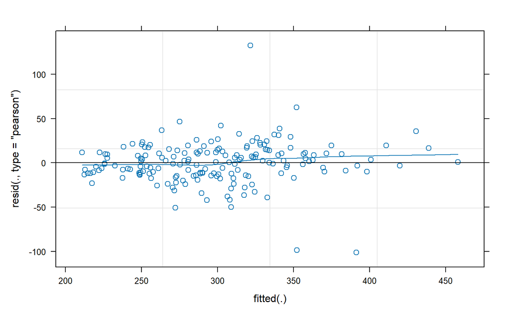

```r
# Gráfico de resíduos padronizados: devem parecer ruído sem padrão
plot(modelo_rc, type = c("p", "smooth"))
```

O ideal é que os pontos não mostrem curva nem leque. Se houver padrão claro, o modelo não está captando bem a estrutura dos dados.

## 12 O que levar para o caso dos esferoides

- Medidas do mesmo sujeito são correlacionadas, não independentes.
- A regressão comum ignora isso e entrega erros-padrão falsos.
- O modelo misto separa o que é efeito fixo (o que interpretamos) do que é variação entre sujeitos (efeito aleatório).
- Começar simples `(1 | Subject)` e ampliar para `(Days | Subject)` só se os dados pedirem é a mesma lógica que usamos nos esferoides, trocando sujeito por esferoide e dia por tempo.

Harrell, em Regression Modeling Strategies, defende modelar explicitamente a estrutura de covariância dos dados em vez de fingir independência; Field, em Discovering Statistics Using R, traz exatamente esse exemplo de modelos multinível como porta de entrada para quem vem da regressão comum.

## 13 Exercícios

1. Rode a regressão comum e o modelo misto. Compare os erros-padrão de `Days`. Por que o do modelo misto é maior?
2. Troque `(Days | Subject)` por `(1 + Days || Subject)` (inclinações aleatórias sem correlação com a interceptação). O AIC melhora ou piora?
3. Use `emmeans` para contrastar o dia 0 com o dia 9. Há diferença significativa?
4. Releia o caso dos esferoides e aponte onde aparece a mesma ideia de interceptação aleatória.

## 14 Referências

- Harrell, F. E. (2015). *Regression Modeling Strategies: With Applications to Linear Models, Logistic and Ordinal Regression, and Survival Analysis*. Springer. (Capítulos sobre modelos de efeitos mistos e estrutura de covariância.)
- Field, A., Miles, J., e Field, Z. (2012). *Discovering Statistics Using R*. Sage. (Capítulo sobre modelos multinível / efeitos mistos.)
- Bates, D., Mächler, M., Bolker, B., e Walker, S. (2015). Fitting Linear Mixed-Effects Models Using lme4. *Journal of Statistical Software*, 67(1), 1 a 48. (O pacote `lme4` e o dataset `sleepstudy`.)